# DATACON - Navazující analýza dle specifikovaných kritérií

Samuel Maštálko, Vratislav Žabka

2025-10-02

Pro analýzu byli vybráni klienti pojištění alespoň v období `2019-01-01` až `2022-12-31` a ve věku `16-29` v roce 2021. Jako datum vakcinace je vybrané datum první dávky a jako očkovaní jsou označeni klienti s alespoň jedním záznamem o očkování. Předpis je označený jako prvopředpis, pokud u daného klienta není sledovaný žádný předpis v minulosti (i před rokem 2019).

Sledované jsou veškeré předpisy v ATC skupině `H02`.

K vrcholu vakcinace došlo `2021-06-16`, jako rozhodné datum je tedy stanoveno `2021-06-23` a podmnožina očkovaných je omezena jen na očkované v rozmezí +- 14 dní od rozhodného data.

- Počet očkovaných jedinců: 60 263
- Počet neočkovaných jedinců: 99 451
- Počet jedinců bez předpisu: 131 130

```r
prescriptions <- dbGetQuery(con,
                          "
                          SELECT
                            c.client_id,
                            c.n_vacc,
                            c.n_presc,
                            c.sex,
                            c.birthyear,
                            2021 - c.birthyear AS age_2021,
                            FIRST(p.date) OVER (PARTITION BY c.client_id ORDER BY p.presc_order ASC) AS first_presc_date,
                            p.date AS presc_date,
                            v.date AS vacc_date,
                            d.drug_form,
                            d.ATC_group,
                            d.Prednison_equiv AS prednison_equiv,
                            d.force AS strength,
                            'CPZP' AS ins_company
                          FROM
                            cpzp_clients c
                          LEFT JOIN cpzp_ins_start_end i ON c.client_id = i.client_id
                          LEFT JOIN cpzp_prescriptions p ON c.client_id = p.client_id
                          LEFT JOIN cpzp_vaccinations v ON c.client_id = v.client_id AND event_order = 1
                          LEFT JOIN cpzp_drugs_catalog d ON p.presc_id  = d.presc_id
                          WHERE
                            i.ins_start_date < '2019-01-01' AND i.ins_end_date > '2022-12-31'
                            AND 2021 - c.birthyear BETWEEN 16 AND 29

                          UNION

                          SELECT
                            c.client_id,
                            c.n_vacc,
                            c.n_presc,
                            c.sex,
                            c.birthyear,
                            2021 - c.birthyear AS age_2021,
                            FIRST(p.date) OVER (PARTITION BY c.client_id ORDER BY p.date ASC) AS first_presc_date,
                            p.date AS presc_date,
                            v.date AS vacc_date,
                            d.drug_form,
                            d.ATC_group,
                            d.Prednison_equiv AS prednison_equiv,
                            d.strength,
                            'OZP' AS ins_company
                          FROM
                            ozp_clients c
                          LEFT JOIN ozp_ins_start_end i ON c.client_id = i.client_id
                          LEFT JOIN ozp_prescriptions p ON c.client_id = p.client_id
                          LEFT JOIN ozp_vaccinations v ON c.client_id = v.client_id AND event_order = 1
                          LEFT JOIN ozp_drugs_catalog d ON p.presc_id = d.presc_id
                          WHERE
                            i.ins_start_date < '2019-01-01' AND (i.ins_end_date IS NULL OR i.ins_end_date > '2022-12-31')
                            AND 2021 - c.birthyear BETWEEN 16 AND 29
                          ") %>%
  mutate(client_id = as.numeric(factor(client_id)),
         vacc_yearmonth = floor_date(vacc_date, unit = "month"),
         presc_yearmonth = floor_date(presc_date, unit = "month"),
         vaccinated = ifelse(n_vacc > 0, "Vakcinace", "Bez vakcinace"),
         sex = ifelse(sex == "Z", "F", sex),
         first_presc_flag = ifelse(!is.na(presc_date) & first_presc_date == presc_date,1,0)) %>%
    filter(
    vaccinated == "Bez vakcinace" |
    (vaccinated == "Vakcinace" &
       between(vacc_date, ymd("2021-06-23") - days(14),
                           ymd("2021-06-23") + days(14)))
  )
```

# 1 DiD Analýza prvopředpisovosti

Sledované období je +- 365 dní od datumu vakcinace a pro nečkované je jako datum vakcinace zvoleno `2021-06-23`. Použitá metrika je počet prvopředpisů ve zvoleném období (před vakcinací, po vakcinaci) na 1 000 dosud nepředepisovaných osob.

Pro p-hodnotu míry změny uvnitř skupin (očkovaní a neočkovaní) je použita metoda prop.test(). Tento přístup není naprosto ideální, protože se nejedná o nezávislé množiny, ale pro orientační sledování je dostačující.

P-hodnota DiD analýzy je měřena v rámci glm modelu `glm(event ~ period * vacc_status, data = indiv_long, family = binomial())` pro interakci kategorických proměnných `period:vacc_status.Vakcinace`.

```r
fake_vacc_date <- as.Date("2021-06-23")

dat <- prescriptions %>%
  mutate(first_presc_date = as.Date(first_presc_date),
         vacc_date = as.Date(vacc_date)) %>%
  filter(is.na(vacc_date) |
           abs(as.numeric(vacc_date - fake_vacc_date)) <= 14) %>%
  mutate(vacc_status = case_when(!is.na(vacc_date) ~ "Vakcinace", TRUE ~ "Bez vakcinace"))


indiv <- dat %>%
  mutate(
    vacc_date_eff = if_else(vacc_status == "Vakcinace", vacc_date, fake_vacc_date),
    obs_start = vacc_date_eff - days(365),
    obs_end   = vacc_date_eff + days(365),

    event_pre  = !is.na(first_presc_date) &
      (first_presc_date >= obs_start & first_presc_date < vacc_date_eff),
    event_post = !is.na(first_presc_date) &
      (first_presc_date >= vacc_date_eff & first_presc_date <= obs_end),

    at_risk_pre  = is.na(first_presc_date) |
      (first_presc_date >= obs_start),
    at_risk_post = is.na(first_presc_date) |
      (first_presc_date >= vacc_date_eff)
  ) %>%
  distinct(client_id, .keep_all = TRUE) %>%
  mutate(
    pre_flag  = as.integer(event_pre),
    post_flag = as.integer(event_post),
    change    = post_flag - pre_flag
  )


rates_df <- indiv %>%
  group_by(vacc_status) %>%
  summarise(
    n_clients        = n(),
    n_atrisk_pre     = sum(at_risk_pre, na.rm = TRUE),
    n_event_pre      = sum(event_pre, na.rm = TRUE),
    rate_pre_per1000  = if_else(n_atrisk_pre > 0, n_event_pre / n_atrisk_pre * 1000, NA_real_),
    n_atrisk_post    = sum(at_risk_post, na.rm = TRUE),
    n_event_post     = sum(event_post, na.rm = TRUE),
    rate_post_per1000 = if_else(n_atrisk_post > 0, n_event_post / n_atrisk_post * 1000, NA_real_),
    .groups = "drop"
  )


within_tests <- rates_df %>%
  rowwise() %>%
  mutate(p_prop = if (n_atrisk_pre > 0 & n_atrisk_post > 0) {
    prop.test(c(n_event_pre, n_event_post),
              c(n_atrisk_pre, n_atrisk_post))$p.value
  } else
    NA_real_) %>%
  ungroup()


indiv_long <- indiv %>%
  select(client_id, vacc_status, pre_flag, post_flag) %>%
  pivot_longer(
    cols = c(pre_flag, post_flag),
    names_to = "period",
    values_to = "event"
  ) %>%
  mutate(period = if_else(period == "pre_flag", 0, 1),
         event = as.integer(event))

did_model <- glm(event ~ period * vacc_status,
                 data = indiv_long,
                 family = binomial())
did_p_value <- coef(summary(did_model))[["period:vacc_statusVakcinace", "Pr(>|z|)"]]

table1 <- rates_df %>%
  mutate(relative_change = rate_post_per1000 / rate_pre_per1000) %>%
  left_join(within_tests %>% select(vacc_status, p_prop), by = "vacc_status") %>%
  transmute(
    vacc_status,
    n_event_pre,
    n_event_post,
    rate_pre = rate_pre_per1000,
    rate_post = rate_post_per1000,
    relative_change,
    p_value = p_prop
  )

rel_changes <- table1 %>%
  select(vacc_status, relative_change)

did_table <- tibble(
  relative_difference = (
    rel_changes %>% filter(vacc_status == "Vakcinace") %>% pull(relative_change)
  ) /
    (
      rel_changes %>% filter(vacc_status == "Bez vakcinace") %>% pull(relative_change)
    ),
  did_p_value = did_p_value
)
```

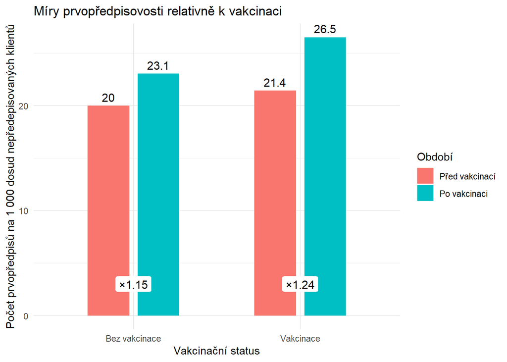

```r
plot_df <- table1 %>%
  select(vacc_status, rate_pre, rate_post, relative_change) %>%
  pivot_longer(
    cols = c(rate_pre, rate_post),
    names_to = "period",
    values_to = "rate"
  ) %>%
  mutate(period = factor(
    period,
    levels = c("rate_pre", "rate_post"),
    labels = c("Před vakcinací", "Po vakcinaci")
  ))

ggplot(plot_df, aes(x = vacc_status, y = rate, fill = period)) +
  geom_col(position = position_dodge(width = 0.6), width = 0.5) +
  geom_text(
    aes(label = round(rate, 1)),
    position = position_dodge(width = 0.6),
    vjust = -0.5,
    size = 4
  ) +
  geom_label(
    data = table1,
    aes(
      x = vacc_status,
      y = 3,
      label = paste0("×", round(relative_change, 2))
    ),
    inherit.aes = FALSE,
    size = 4,
    fill = "white",
    label.size = 0
  ) +

  labs(title = "Míry prvopředpisovosti relativně k vakcinaci",
       x = "Vakcinační status",
       y = "Počet prvopředpisů na 1 000 dosud nepředepisovaných klientů",
       fill = "Období") +
  theme_minimal()
```

Podle grafu je patrná vyšší prvopředpisovost v obou skupinách s nižším nárustem u neočkované populace.

```r
table1 %>%
  transmute(
    `Vakcinační status` = vacc_status,
    `Míra před` = rate_pre,
    `Míra po` = rate_post,
    `Relativní změna` = relative_change,
    `p-hodnota` = p_value
  ) %>%
  kable(format = "html", caption = "Porovnání míry prvopředpisovosti očkovaných a neočkovaných") %>%
  kable_styling(
    bootstrap_options = c("striped", "hover", "condensed"),
    full_width = TRUE
  )
```

Porovnání míry prvopředpisovosti očkovaných a neočkovaných

| Vakcinační status | Míra před | Míra po | Relativní změna | p-hodnota |
| --- | --- | --- | --- | --- |
| Bez vakcinace | 20.00426 | 23.05720 | 1.152614 | 1.07e-05 |
| Vakcinace | 21.43565 | 26.52687 | 1.237512 | 1.00e-07 |

Relativní změna je v obou skupinách statisticky významná.

````r
cat("```\n", paste(capture.output(print(summary(
  did_model
))), collapse = "\n"), "\n```")
````

```
Call:
glm(formula = event ~ period * vacc_status, family = binomial(),
    data = indiv_long)

Coefficients:
                            Estimate Std. Error  z value Pr(>|z|)
(Intercept)                 -4.00328    0.02389 -167.540  < 2e-16 ***
period                       0.12419    0.03283    3.783 0.000155 ***
vacc_statusVakcinace         0.06092    0.03820    1.595 0.110774
period:vacc_statusVakcinace  0.07134    0.05199    1.372 0.170005
---
Signif. codes:  0 '***' 0.001 '**' 0.01 '*' 0.05 '.' 0.1 ' ' 1

(Dispersion parameter for binomial family taken to be 1)

    Null deviance: 62200  on 319427  degrees of freedom
Residual deviance: 62147  on 319424  degrees of freedom
AIC: 62155

Number of Fisher Scoring iterations: 6
```

DiD analýza ovšem nevykazuje statisticky významný rozdíl mezi skupinami (p-hodnota interkace 0.17), jediný významný prediktor prvopředpisovosti je proměnná `period` (čili období před nebo po).

# 2 SCCS Prvopředpisy

Zde je použita metoda [SCCS](https://cran.r-project.org/web/packages/SCCS/SCCS.pdf), konkrétně tedy `standardsccs()`. Samotný model je vydefinován `coxph(formula = Surv(rep(), event) ~ exposure_start_day + strata(indivL) + offset(log(interval)), data = chopdat, method = "exact")` (tedy Coxova regrese proporcionálních rizik). Zvolené období expozice jsou 0-29, 30-89, 90-179, 180-269 a 270-365 dní od vakcinace. Každé období je potom porovnáno s ostatními (včetně baseline 365 dní před vakcinací) a míra proporcionálního rizika (HR) je poté vyjádřena jako `exp(coef)` nebo jako log(HR) `coef`. Pro testování rozdílů mezi skupinami byl použit Waldův test na rozdíl `log(HR)` v rámci DiD analýzy.

## 2.1 Poměrné riziko prvopředpisů očkovaných

````r
vaccinated_prescribed <- prescriptions %>%
  filter(
    vaccinated == "Vakcinace",
    first_presc_date >= vacc_date - days(365),
    first_presc_date <= vacc_date + days(365),
    first_presc_flag == 1
  ) %>%
  transmute(
    person_id = client_id,
    exposure_start_date = vacc_date,
    event_date = presc_date,
    observation_start_date = vacc_date - days(365),
    observation_end_date = vacc_date + days(365)
  )

sccs_vaccinated <- vaccinated_prescribed %>%
  mutate(
    event_day = as.integer(event_date - observation_start_date),
    exposure_start_day = as.integer(exposure_start_date - observation_start_date),
    observation_start_day = 0,
    observation_end_day = as.integer(observation_end_date - observation_start_date)
  )

sccs_result_vaccinated <- standardsccs(
  formula = event_day ~ exposure_start_day,
  indiv = person_id,
  astart = observation_start_day,
  aend = observation_end_day,
  aevent = event_day,
  adrug = exposure_start_day,
  aedrug = exposure_start_day + 365,
  expogrp = list(c(0, 30, 90, 180, 270)),
  data = sccs_vaccinated
)

cat("```\n", paste(capture.output(print(
  sccs_result_vaccinated
)), collapse = "\n"), "\n```")
````

```
 Call:
coxph(formula = Surv(rep(1, 15216L), event) ~ exposure_start_day +
    strata(indivL) + offset(log(interval)), data = chopdat, method = "exact")

  n= 15216, number of events= 2536

                       coef exp(coef) se(coef)     z Pr(>|z|)
exposure_start_day1 0.16333   1.17742  0.09940 1.643  0.10037
exposure_start_day2 0.06395   1.06604  0.07647 0.836  0.40295
exposure_start_day3 0.14514   1.15620  0.06269 2.315  0.02060 *
exposure_start_day4 0.17823   1.19510  0.06189 2.880  0.00398 **
exposure_start_day5 0.31167   1.36570  0.05744 5.426 5.76e-08 ***
---
Signif. codes:  0 '***' 0.001 '**' 0.01 '*' 0.05 '.' 0.1 ' ' 1

                    exp(coef) exp(-coef) lower .95 upper .95
exposure_start_day1     1.177     0.8493    0.9690     1.431
exposure_start_day2     1.066     0.9380    0.9177     1.238
exposure_start_day3     1.156     0.8649    1.0225     1.307
exposure_start_day4     1.195     0.8368    1.0586     1.349
exposure_start_day5     1.366     0.7322    1.2203     1.528

Concordance= 0.73  (se = 0.007 )
Likelihood ratio test= 32.45  on 5 df,   p=5e-06
Wald test            = 33.3  on 5 df,   p=3e-06
Score (logrank) test = 33.48  on 5 df,   p=3e-06
```

Všeobecně je riziko větší ve všech sledovaných periodách. Statistická významnost je nejvyráznější v poslední expozici (270+ dní).

## 2.2 Poměrné riziko prvopředpisů neočkovaných

````r
unvaccinated_prescribed <- prescriptions %>%
  filter(
    vaccinated == "Bez vakcinace",
    first_presc_date >= as.Date("2021-06-23") - days(365),
    first_presc_date <= as.Date("2021-06-23") + days(365),
    first_presc_flag == 1
  ) %>%
  transmute(
    person_id = client_id,
    exposure_start_date = as.Date("2021-06-23"),
    event_date = presc_date,
    observation_start_date = as.Date("2021-06-23") - days(365),
    observation_end_date = as.Date("2021-06-23") + days(365)
  )

sccs_unvaccinated <- unvaccinated_prescribed %>%
  mutate(
    event_day = as.integer(event_date - observation_start_date),
    exposure_start_day = as.integer(exposure_start_date - observation_start_date),
    observation_start_day = 0,
    observation_end_day = as.integer(observation_end_date - observation_start_date)
  )

sccs_result_unvaccinated <- standardsccs(
  formula = event_day ~ exposure_start_day,
  indiv = person_id,
  astart = observation_start_day,
  aend = observation_end_day,
  aevent = event_day,
  adrug = exposure_start_day,
  aedrug = exposure_start_day + 365,
  expogrp = list(c(0, 30, 90, 180, 270)),
  data = sccs_unvaccinated
)

cat("```\n", paste(capture.output(print(
  sccs_result_unvaccinated
)), collapse = "\n"), "\n```")
````

```
 Call:
coxph(formula = Surv(rep(1, 22782L), event) ~ exposure_start_day +
    strata(indivL) + offset(log(interval)), data = chopdat, method = "exact")

  n= 22782, number of events= 3797

                       coef exp(coef) se(coef)     z Pr(>|z|)
exposure_start_day1 0.31096   1.36474  0.07457 4.170 3.05e-05 ***
exposure_start_day2 0.14845   1.16003  0.05918 2.508 0.012126 *
exposure_start_day3 0.08365   1.08724  0.05151 1.624 0.104378
exposure_start_day4 0.00308   1.00309  0.05318 0.058 0.953819
exposure_start_day5 0.16847   1.18349  0.04861 3.466 0.000529 ***
---
Signif. codes:  0 '***' 0.001 '**' 0.01 '*' 0.05 '.' 0.1 ' ' 1

                    exp(coef) exp(-coef) lower .95 upper .95
exposure_start_day1     1.365     0.7327    1.1792     1.580
exposure_start_day2     1.160     0.8620    1.0330     1.303
exposure_start_day3     1.087     0.9198    0.9828     1.203
exposure_start_day4     1.003     0.9969    0.9038     1.113
exposure_start_day5     1.183     0.8450    1.0759     1.302

Concordance= 0.726  (se = 0.006 )
Likelihood ratio test= 28.75  on 5 df,   p=3e-05
Wald test            = 29.8  on 5 df,   p=2e-05
Score (logrank) test = 29.93  on 5 df,   p=2e-05
```

## 2.3 Porovnání poměrných rizik

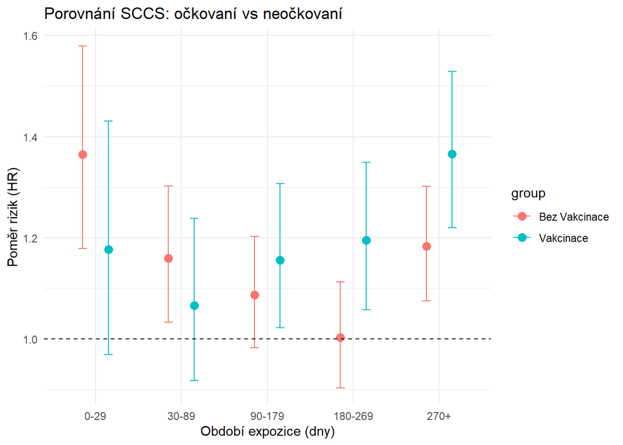

```r
coef_unvax <- sccs_result_unvaccinated$coefficients
conf_unvax <- sccs_result_unvaccinated$conf.int

df_unvax <- data.frame(
  term = rownames(coef_unvax),
  logHR = coef_unvax[, "coef"],
  SE = coef_unvax[, "se(coef)"],
  HR = coef_unvax[, "exp(coef)"],
  conf.low = conf_unvax[, "lower .95"],
  conf.high = conf_unvax[, "upper .95"]
)

coef_vax <- sccs_result_vaccinated$coefficients
conf_vax <- sccs_result_vaccinated$conf.int

df_vax <- data.frame(
  term = rownames(coef_vax),
  logHR = coef_vax[, "coef"],
  SE = coef_vax[, "se(coef)"],
  HR = coef_vax[, "exp(coef)"],
  conf.low = conf_vax[, "lower .95"],
  conf.high = conf_vax[, "upper .95"]
)

df_unvax <- df_unvax %>% mutate(group = "Bez Vakcinace")
df_vax <- df_vax %>% mutate(group = "Vakcinace")

combined <- bind_rows(df_vax, df_unvax)

combined$period <- as.integer(gsub("exposure_start_day", "", combined$term))

start_days <- c(0, 30, 90, 180, 270)
end_days   <- c(29, 89, 179, 269, Inf)

period_labels <- ifelse(is.infinite(end_days),
                        paste0(start_days, "+"),
                        paste0(start_days, "-", end_days))

combined$period_label <- factor(combined$period,
                                levels = seq_along(period_labels),
                                labels = period_labels)

ggplot(combined, aes(x = period_label, y = HR, color = group)) +
  geom_point(position = position_dodge(width = 0.6), size = 3) +
  geom_errorbar(
    aes(ymin = conf.low, ymax = conf.high),
    width = 0.2,
    position = position_dodge(width = 0.6)
  ) +
  geom_hline(yintercept = 1, linetype = "dashed") +
  labs(x = "Období expozice (dny)", y = "Poměr rizik (HR)", title = "Porovnání SCCS: očkovaní vs neočkovaní") +
  theme_minimal()
```

Patrná je “výměna” pořadí míry rizika zhruba v obodbí 90-179 dní od vakcinace. Všeobecně je ale také zřejmý srovnatelný trend růstu a poklesu.

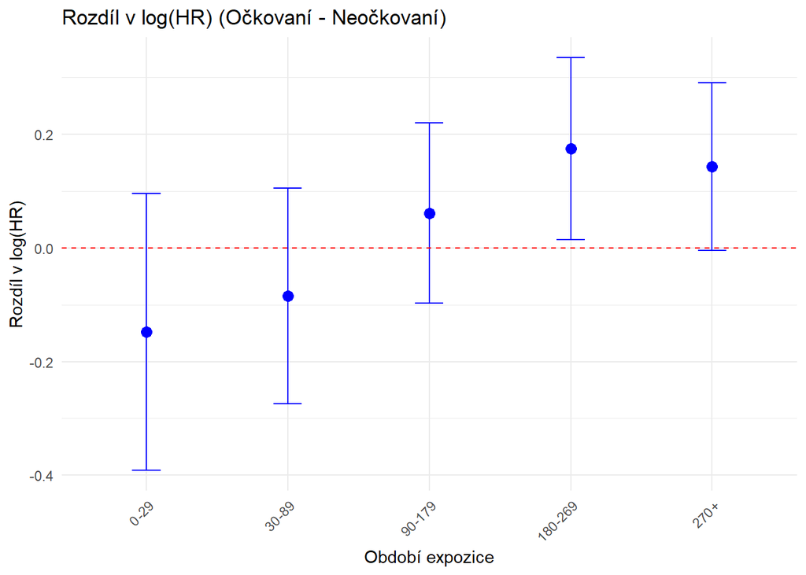

```r
vax_df <- combined %>%
  filter(group == "Vakcinace") %>%
  rename_with( ~ paste0(., "_vax"), -c(period, period_label))

unvax_df <- combined %>%
  filter(group == "Bez Vakcinace") %>%
  rename_with( ~ paste0(., "_unvax"), -c(period, period_label))

df_diff <- inner_join(vax_df, unvax_df, by = c("period", "period_label"))

df_diff <- df_diff %>%
  mutate(
    logHR_diff = logHR_vax - logHR_unvax,
    se_diff = sqrt(SE_vax^2 + SE_unvax^2),
    ci_low = logHR_diff - 1.96 * se_diff,
    ci_high = logHR_diff + 1.96 * se_diff
  )

ggplot(df_diff, aes(x = period_label, y = logHR_diff)) +
  geom_point(color = "blue", size = 3) +
  geom_errorbar(aes(ymin = ci_low, ymax = ci_high),
                width = 0.2,
                color = "blue") +
  geom_hline(yintercept = 0,
             linetype = "dashed",
             color = "red") +
  labs(title = "Rozdíl v log(HR) (Očkovaní - Neočkovaní)", x = "Období expozice", y = "Rozdíl v log(HR)") +
  theme_minimal() +
  theme(axis.text.x = element_text(angle = 45, hjust = 1))
```

Logaritmus proporcionálních rizik je možné také porovnat mezi sebou a určit “více rizikovou skupinu” pro každé období. Zde je stejně patrná výměna pozic z hlediska relativního rizika v neprospěch očkovaných v období 90-179 dní od vakcinace.

```r
common_terms <- intersect(df_vax$term, df_unvax$term)

did_results <- data.frame(
  term = character(),
  period_label = character(),
  logHR_vax = numeric(),
  logHR_unvax = numeric(),
  DiD_logHR = numeric(),
  DiD_SE = numeric(),
  Z = numeric(),
  P_value = numeric(),
  stringsAsFactors = FALSE
)

for (term in common_terms) {
  logHR_vax <- df_vax %>% filter(term == !!term) %>% pull(logHR)
  SE_vax    <- df_vax %>% filter(term == !!term) %>% pull(SE)

  logHR_unvax <- df_unvax %>% filter(term == !!term) %>% pull(logHR)
  SE_unvax    <- df_unvax %>% filter(term == !!term) %>% pull(SE)

  DiD_logHR <- logHR_vax - logHR_unvax
  DiD_SE <- sqrt(SE_vax^2 + SE_unvax^2)
  Z <- DiD_logHR / DiD_SE
  P_value <- 2 * pnorm(-abs(Z))

  period_idx <- as.integer(gsub("exposure_start_day", "", term))
  period_label <- period_labels[period_idx]

  did_results <- rbind(
    did_results,
    data.frame(
      term = term,
      period_label = period_label,
      logHR_vax = logHR_vax,
      logHR_unvax = logHR_unvax,
      DiD_logHR = DiD_logHR,
      DiD_SE = DiD_SE,
      Z = Z,
      P_value = P_value
    )
  )
}

did_results %>%
  transmute(
    Období = period_label,
    `log(HR) Vakcinace` = logHR_vax,
    `log(HR) Bez vakcinace` = logHR_unvax,
    `DiD log(HR)` = DiD_logHR,
    p_value = P_value
  ) %>%
  kable(format = "html", caption = "Porovnání rizik očkovaných a neočkovaných (SCCS)") %>%
  kable_styling(
    bootstrap_options = c("striped", "hover", "condensed"),
    full_width = TRUE
  )
```

Porovnání rizik očkovaných a neočkovaných (SCCS)

| Období | log(HR) Vakcinace | log(HR) Bez vakcinace | DiD log(HR) | p_value |
| --- | --- | --- | --- | --- |
| 0-29 | 0.1633251 | 0.3109647 | -0.1476397 | 0.2347913 |
| 30-89 | 0.0639526 | 0.1484458 | -0.0844932 | 0.3821972 |
| 90-179 | 0.1451427 | 0.0836458 | 0.0614969 | 0.4484746 |
| 180-269 | 0.1782285 | 0.0030799 | 0.1751485 | 0.0318425 |
| 270+ | 0.3116674 | 0.1684647 | 0.1432027 | 0.0570177 |

Jediný statisticky významný výsledek je následně v období 180-269 dní od vakcinace (což je patrné i na grafu výše) s pozitivním efektem pro neočkované (nižší poměrné riziko).

# 3 SCCS Předpisy celkem

Metodika je téměř identická jako u předchozí analýzy. V tomto případě jsou ale zahrnuty veškeré předpisy a z důvodu stejné váhy jsou předpisy injekcí a infuzí v rámci 10-denního okna agregovány do jednoho předpisu.

## 3.1 Poměrné riziko předpisů očkovaných

````r
vaccinated_prescribed_multi <- prescriptions %>%
  filter(
    vaccinated == "Vakcinace",
    presc_date >= vacc_date - days(365),
    presc_date <= vacc_date + days(365)
  ) %>%
  transmute(
    person_id = client_id,
    exposure_start_date = vacc_date,
    event_date = presc_date,
    observation_start_date = vacc_date - days(365),
    observation_end_date = vacc_date + days(365),
    drug_form = tolower(drug_form),
    inj_or_inf = str_detect(drug_form, "injekční|infuzní")
  ) %>%
  arrange(person_id, event_date) %>%
  group_by(person_id) %>%
  mutate(keep = {
    keep_vec <- logical(n())
    next_window_start <- as.Date(NA)

    for (i in seq_along(event_date)) {
      if (inj_or_inf[i]) {
        if (is.na(next_window_start) || event_date[i] > next_window_start) {
          keep_vec[i] <- TRUE
          next_window_start <- event_date[i] + 10
        } else {
          keep_vec[i] <- FALSE
        }
      } else {
        keep_vec[i] <- TRUE
      }
    }
    keep_vec
  }) %>%
  filter(keep) %>%
  ungroup() %>%
  select(-keep, -drug_form, -inj_or_inf)

sccs_vaccinated_multi <- vaccinated_prescribed_multi %>%
  mutate(
    event_day = as.integer(event_date - observation_start_date),
    exposure_start_day = as.integer(exposure_start_date - observation_start_date),
    observation_start_day = 0,
    observation_end_day = as.integer(observation_end_date - observation_start_date)
  )

sccs_result_vaccinated_multi <- standardsccs(
  formula = event_day ~ exposure_start_day,
  indiv = person_id,
  astart = observation_start_day,
  aend = observation_end_day,
  aevent = event_day,
  adrug = exposure_start_day,
  aedrug = exposure_start_day + 365,
  expogrp = list(c(0, 30, 90, 180, 270)),
  data = sccs_vaccinated_multi
)

cat("```\n", paste(capture.output(print(
  sccs_result_vaccinated_multi
)), collapse = "\n"), "\n```")
````

```
 Call:
coxph(formula = Surv(rep(1, 34344L), event) ~ exposure_start_day +
    strata(indivL) + offset(log(interval)), data = chopdat, method = "exact")

  n= 34344, number of events= 5724

                       coef exp(coef) se(coef)     z Pr(>|z|)
exposure_start_day1 0.08028   1.08359  0.06911 1.162 0.245389
exposure_start_day2 0.17440   1.19053  0.04885 3.570 0.000357 ***
exposure_start_day3 0.13988   1.15013  0.04205 3.327 0.000879 ***
exposure_start_day4 0.18827   1.20716  0.04127 4.562 5.06e-06 ***
exposure_start_day5 0.34109   1.40647  0.03803 8.968  < 2e-16 ***
---
Signif. codes:  0 '***' 0.001 '**' 0.01 '*' 0.05 '.' 0.1 ' ' 1

                    exp(coef) exp(-coef) lower .95 upper .95
exposure_start_day1     1.084     0.9229    0.9463     1.241
exposure_start_day2     1.191     0.8400    1.0818     1.310
exposure_start_day3     1.150     0.8695    1.0591     1.249
exposure_start_day4     1.207     0.8284    1.1134     1.309
exposure_start_day5     1.406     0.7110    1.3054     1.515

Concordance= 0.728  (se = 0.005 )
Likelihood ratio test= 86.46  on 5 df,   p=<2e-16
Wald test            = 88.8  on 5 df,   p=<2e-16
Score (logrank) test = 89.39  on 5 df,   p=<2e-16
```

Zde je opět riziko ve všech případech vyšší s rostoucí tendencí v čase. Statisticky významné jsou téměř všechny výsledky vyjma prvního okna.

## 3.2 Poměrné riziko předpisů neočkovaných

````r
unvaccinated_prescribed_multi <- prescriptions %>%
  filter(
    vaccinated == "Bez vakcinace",
    presc_date >= as.Date("2021-06-23") - days(365),
    presc_date <= as.Date("2021-06-23") + days(365)
  ) %>%
  transmute(
    person_id = client_id,
    exposure_start_date = as.Date("2021-06-23"),
    event_date = presc_date,
    observation_start_date = as.Date("2021-06-23") - days(365),
    observation_end_date = as.Date("2021-06-23") + days(365),
    drug_form = tolower(drug_form),
    inj_or_inf = str_detect(drug_form, "injekční|infuzní")
  ) %>%
  arrange(person_id, event_date) %>%
  group_by(person_id) %>%
  mutate(keep = {
    keep_vec <- logical(n())
    next_window_start <- as.Date(NA)

    for (i in seq_along(event_date)) {
      if (inj_or_inf[i]) {
        if (is.na(next_window_start) || event_date[i] > next_window_start) {
          keep_vec[i] <- TRUE
          next_window_start <- event_date[i] + 10
        } else {
          keep_vec[i] <- FALSE
        }
      } else {
        keep_vec[i] <- TRUE
      }
    }
    keep_vec
  }) %>%
  filter(keep) %>%
  ungroup() %>%
  select(-keep, -drug_form, -inj_or_inf)

sccs_unvaccinated_multi <- unvaccinated_prescribed_multi %>%
  mutate(
    event_day = as.integer(event_date - observation_start_date),
    exposure_start_day = as.integer(exposure_start_date - observation_start_date),
    observation_start_day = 0,
    observation_end_day = as.integer(observation_end_date - observation_start_date)
  )

sccs_result_unvaccinated_multi <- standardsccs(
  formula = event_day ~ exposure_start_day,
  indiv = person_id,
  astart = observation_start_day,
  aend = observation_end_day,
  aevent = event_day,
  adrug = exposure_start_day,
  aedrug = exposure_start_day + 365,
  expogrp = list(c(0, 30, 90, 180, 270)),
  data = sccs_unvaccinated_multi
)

cat("```\n", paste(capture.output(print(
  sccs_result_unvaccinated_multi
)), collapse = "\n"), "\n```")
````

```
 Call:
coxph(formula = Surv(rep(1, 55518L), event) ~ exposure_start_day +
    strata(indivL) + offset(log(interval)), data = chopdat, method = "exact")

  n= 55518, number of events= 9253

                       coef exp(coef) se(coef)     z Pr(>|z|)
exposure_start_day1 0.18764   1.20640  0.05098 3.681 0.000232 ***
exposure_start_day2 0.12420   1.13225  0.03865 3.214 0.001311 **
exposure_start_day3 0.12504   1.13320  0.03276 3.817 0.000135 ***
exposure_start_day4 0.10385   1.10943  0.03303 3.144 0.001669 **
exposure_start_day5 0.22917   1.25756  0.03071 7.462  8.5e-14 ***
---
Signif. codes:  0 '***' 0.001 '**' 0.01 '*' 0.05 '.' 0.1 ' ' 1

                    exp(coef) exp(-coef) lower .95 upper .95
exposure_start_day1     1.206     0.8289     1.092     1.333
exposure_start_day2     1.132     0.8832     1.050     1.221
exposure_start_day3     1.133     0.8825     1.063     1.208
exposure_start_day4     1.109     0.9014     1.040     1.184
exposure_start_day5     1.258     0.7952     1.184     1.336

Concordance= 0.728  (se = 0.004 )
Likelihood ratio test= 67.24  on 5 df,   p=4e-13
Wald test            = 68.13  on 5 df,   p=3e-13
Score (logrank) test = 68.33  on 5 df,   p=2e-13
```

U neočkované populace dochází k menšímu výkyvu a riziko po vakcinaci je stabilnější. I v tomto případě je ale vždy vyšší.

## 3.3 Porovnání poměrného rizika

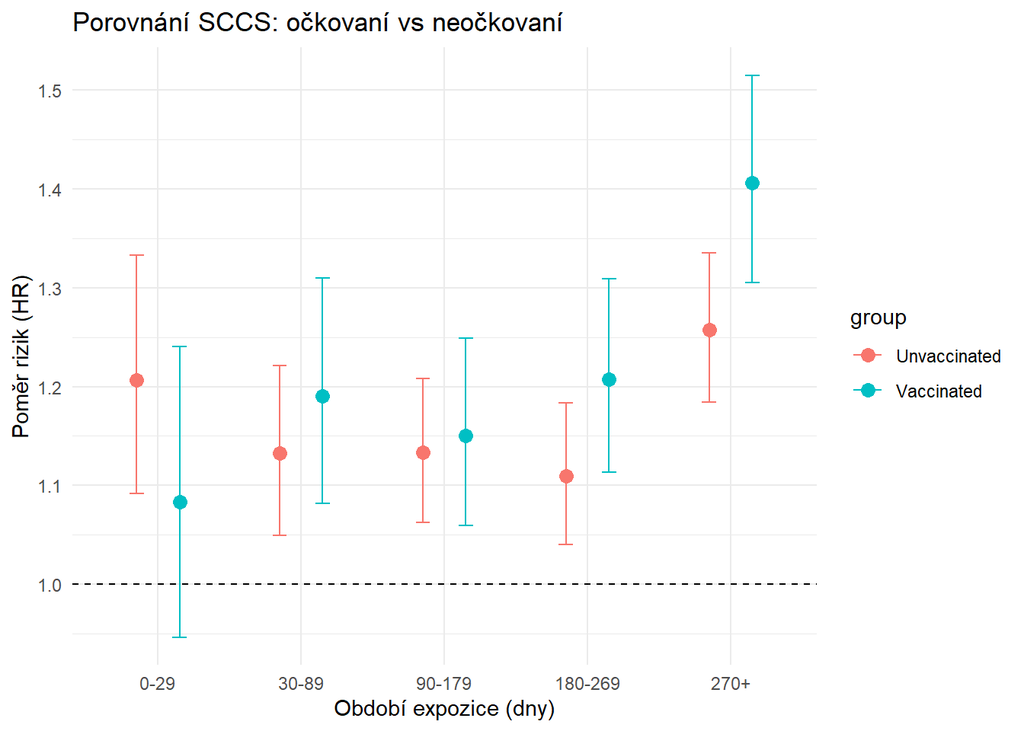

```r
coef_unvax <- sccs_result_unvaccinated_multi$coefficients
conf_unvax <- sccs_result_unvaccinated_multi$conf.int

df_unvax <- data.frame(
  term = rownames(coef_unvax),
  logHR = coef_unvax[, "coef"],
  SE = coef_unvax[, "se(coef)"],
  HR = coef_unvax[, "exp(coef)"],
  conf.low = conf_unvax[, "lower .95"],
  conf.high = conf_unvax[, "upper .95"]
)

coef_vax <- sccs_result_vaccinated_multi$coefficients
conf_vax <- sccs_result_vaccinated_multi$conf.int

df_vax <- data.frame(
  term = rownames(coef_vax),
  logHR = coef_vax[, "coef"],
  SE = coef_vax[, "se(coef)"],
  HR = coef_vax[, "exp(coef)"],
  conf.low = conf_vax[, "lower .95"],
  conf.high = conf_vax[, "upper .95"]
)

df_unvax <- df_unvax %>% mutate(group = "Unvaccinated")
df_vax <- df_vax %>% mutate(group = "Vaccinated")

combined <- bind_rows(df_vax, df_unvax)

combined$period <- as.integer(gsub("exposure_start_day", "", combined$term))

start_days <- c(0, 30, 90, 180, 270)
end_days   <- c(29, 89, 179, 269, Inf)

period_labels <- ifelse(is.infinite(end_days),
                        paste0(start_days, "+"),
                        paste0(start_days, "-", end_days))

combined$period_label <- factor(combined$period,
                                levels = seq_along(period_labels),
                                labels = period_labels)

ggplot(combined, aes(x = period_label, y = HR, color = group)) +
  geom_point(position = position_dodge(width = 0.6), size = 3) +
  geom_errorbar(
    aes(ymin = conf.low, ymax = conf.high),
    width = 0.2,
    position = position_dodge(width = 0.6)
  ) +
  geom_hline(yintercept = 1, linetype = "dashed") +
  labs(x = "Období expozice (dny)", y = "Poměr rizik (HR)", title = "Porovnání SCCS: očkovaní vs neočkovaní") +
  theme_minimal()
```

Všeobecný trend vykazuje podobné známky jako trend prvopředpisů. K “výměně pozic” dochází ale už ve druhém sledovaném období (tedy 30-89 dní od vakcinace).

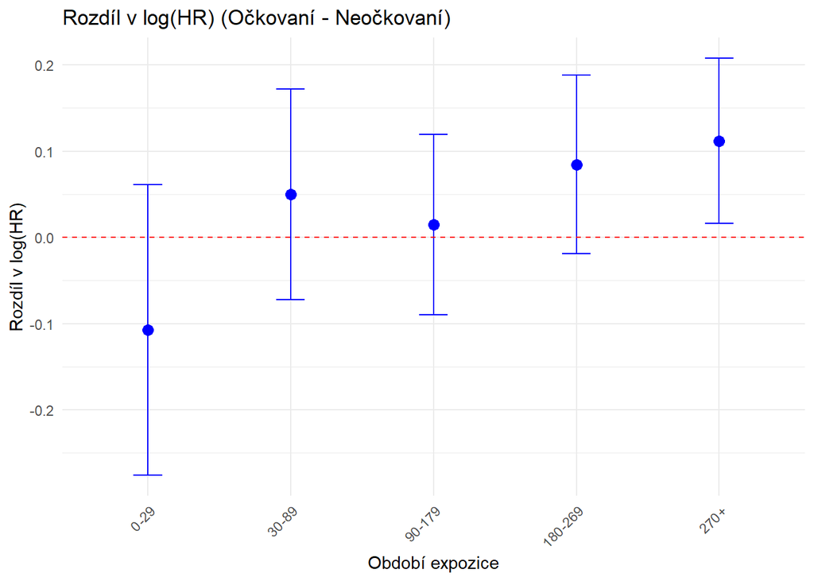

```r
vax_df <- combined %>%
  filter(group == "Vaccinated") %>%
  rename_with( ~ paste0(., "_vax"), -c(period, period_label))

unvax_df <- combined %>%
  filter(group == "Unvaccinated") %>%
  rename_with( ~ paste0(., "_unvax"), -c(period, period_label))

df_diff <- inner_join(vax_df, unvax_df, by = c("period", "period_label"))

df_diff <- df_diff %>%
  mutate(
    logHR_diff = logHR_vax - logHR_unvax,
    se_diff = sqrt(SE_vax^2 + SE_unvax^2),
    ci_low = logHR_diff - 1.96 * se_diff,
    ci_high = logHR_diff + 1.96 * se_diff
  )

ggplot(df_diff, aes(x = period_label, y = logHR_diff)) +
  geom_point(color = "blue", size = 3) +
  geom_errorbar(aes(ymin = ci_low, ymax = ci_high),
                width = 0.2,
                color = "blue") +
  geom_hline(yintercept = 0,
             linetype = "dashed",
             color = "red") +
  labs(title = "Rozdíl v log(HR) (Očkovaní - Neočkovaní)", x = "Období expozice", y = "Rozdíl v log(HR)") +
  theme_minimal() +
  theme(axis.text.x = element_text(angle = 45, hjust = 1))
```

Porovnání log(HR) opět potvrzuje zjištění z předchozího grafu s rostoucím vyšším rizikem pro očkované ke konci.

```r
common_terms <- intersect(df_vax$term, df_unvax$term)

did_results <- data.frame(
  term = character(),
  period_label = character(),
  logHR_vax = numeric(),
  logHR_unvax = numeric(),
  DiD_logHR = numeric(),
  DiD_SE = numeric(),
  Z = numeric(),
  P_value = numeric(),
  stringsAsFactors = FALSE
)

for (term in common_terms) {
  logHR_vax <- df_vax %>% filter(term == !!term) %>% pull(logHR)
  SE_vax    <- df_vax %>% filter(term == !!term) %>% pull(SE)

  logHR_unvax <- df_unvax %>% filter(term == !!term) %>% pull(logHR)
  SE_unvax    <- df_unvax %>% filter(term == !!term) %>% pull(SE)

  DiD_logHR <- logHR_vax - logHR_unvax
  DiD_SE <- sqrt(SE_vax^2 + SE_unvax^2)
  Z <- DiD_logHR / DiD_SE
  P_value <- 2 * pnorm(-abs(Z))

  period_idx <- as.integer(gsub("exposure_start_day", "", term))
  period_label <- period_labels[period_idx]

  did_results <- rbind(
    did_results,
    data.frame(
      term = term,
      period_label = period_label,
      logHR_vax = logHR_vax,
      logHR_unvax = logHR_unvax,
      DiD_logHR = DiD_logHR,
      DiD_SE = DiD_SE,
      Z = Z,
      P_value = P_value
    )
  )
}

did_results %>%
  transmute(
    Období = period_label,
    `log(HR) Vakcinace` = logHR_vax,
    `log(HR) Bez vakcinace` = logHR_unvax,
    `DiD log(HR)` = DiD_logHR,
    p_value = P_value
  ) %>%
  kable(format = "html", caption = "Porovnání rizik (SCCS) očkovaných a neočkovaných") %>%
  kable_styling(
    bootstrap_options = c("striped", "hover", "condensed"),
    full_width = TRUE
  )
```

Porovnání rizik (SCCS) očkovaných a neočkovaných

| Období | log(HR) Vakcinace | log(HR) Bez vakcinace | DiD log(HR) | p_value |
| --- | --- | --- | --- | --- |
| 0-29 | 0.0802831 | 0.1876403 | -0.1073572 | 0.2112595 |
| 30-89 | 0.1743964 | 0.1242044 | 0.0501920 | 0.4203968 |
| 90-179 | 0.1398752 | 0.1250436 | 0.0148315 | 0.7808270 |
| 180-269 | 0.1882717 | 0.1038474 | 0.0844243 | 0.1102426 |
| 270+ | 0.3410857 | 0.2291712 | 0.1119145 | 0.0220588 |

Jediný statisticky významný výsledek je pro poslední sledované období s vyšší mírou rizika pro očkované.